# Thera_Bank Project_Final

### Gradient Boost Classifier

### GridSearchCV

**Let's try using AdaBoost classifier as the estimator for initial predictions**

```python
gbc_init = GradientBoostingClassifier(init=AdaBoostClassifier(random_state=1),random_state=1)
gbc_init.fit(X_train,y_train)
```

```
GradientBoostingClassifier(init=AdaBoostClassifier(random_state=1),
                           random_state=1)
```

```python
#Using above defined function to get accuracy, recall and precision on train and test set
#Calculating different metrics
gbc_init_score = get_metrics_score(gbc_init,X_train,X_test,y_train,y_test)
```

```
Accuracy on training set :  0.9747460496613995
Accuracy on test set :  0.9657782165185916
Recall on training set :  0.8779631255487269
Recall on test set :  0.8627049180327869
Precision on training set :  0.9615384615384616
Precision on test set :  0.9192139737991266
```

- The model generalized well using Adaboost Classification as the initial estimator for GBC.

```python
%%time

# Creating a Pipeline
gb_pipe= make_pipeline(StandardScaler(),
                        GradientBoostingClassifier(random_state=1))

# Grid of parameters to pass into Grid
gb_param = {
       "gradientboostingclassifier__subsample": [0.8,0.9,1],
       "gradientboostingclassifier__n_estimators": np.arange(15,180,15),
       "gradientboostingclassifier__max_depth":[1,3,5,7,9],
       "gradientboostingclassifier__learning_rate":[0.1,0.01,0.2,0.05,1],
       "gradientboostingclassifier__max_features": [0.7,0.8,0.9,1],

}

# Type of scoring used to compare parameter combinations
scorer = metrics.make_scorer(metrics.recall_score)

grid_cvg = GridSearchCV(estimator = gb_pipe,
                    param_grid = gb_param , # Dictionary or list of parameters of models or function in which
                                            # GridSearchCV have to select the best.
                    scoring = scorer, #Evaluating metric for the model performance to decide the best
                    verbose=2 , # no. of times the model has to be fit
                    cv = 5, n_jobs= -1 # Signifies the number of splits that is needed for cross validation. But default is 5
                   )

# Fitting parameters in GridSeachCV
grid_cvg.fit(X_train, y_train)

print(
    "Best Parameters:{} \nScore: {}".format(grid_cvg.best_params_, grid_cvg.best_score_)
)
```

```
Fitting 5 folds for each of 3300 candidates, totalling 16500 fits
Best Parameters:{'gradientboostingclassifier__learning_rate': 0.2, 'gradientboostingclassifier__max_depth': 3, 'gradientboostingclassifier__max_features': 0.7, 'gradientboostingclassifier__n_estimators': 165, 'gradientboostingclassifier__subsample': 1}
Score: 0.878858489836927
Wall time: 1h 4min 47s
```

```python
# Creating new pipeline with best parameters
gbc_Gtuned = make_pipeline(
    (StandardScaler()),
  GradientBoostingClassifier(
      init=AdaBoostClassifier(random_state=1),
           learning_rate = 0.2,
           max_depth=3,
           max_features=0.7,
           n_estimators=165,
           subsample= 1,
           random_state=1,
    ),
)

# Fit the model on training data
gbc_Gtuned.fit(X_train, y_train)
```

```
Pipeline(steps=[('standardscaler', StandardScaler()),
                ('gradientboostingclassifier',
                 GradientBoostingClassifier(init=AdaBoostClassifier(random_state=1),
                                            learning_rate=0.2, max_features=0.7,
                                            n_estimators=165, random_state=1,
                                            subsample=1))])
```

```
Accuracy on training set :  0.9926636568848759
Accuracy on test set :  0.9746627179993419
Recall on training set :  0.971027216856892
Recall on test set :  0.9098360655737705
Precision on training set :  0.9831111111111112
Precision on test set :  0.9308176100628931
```

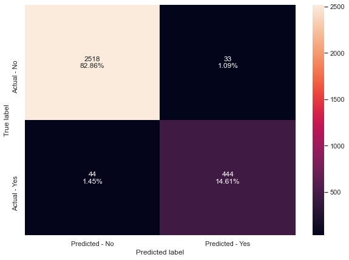

```python
#Calculating different metrics
scores_gbc_Gtuned=get_metrics_score(gbc_Gtuned,X_train,X_test,y_train,y_test)

# creating confusion matrix
make_confusion_matrix(gbc_Gtuned,y_test)
```

- The model is slightly overfitting.
- The model is doing a fairly good job at identifying potential card subscribers.

### RandomizedSearchCV

```python
%%time

# Creating pipeline
gb_pipe= make_pipeline(StandardScaler(),
                        GradientBoostingClassifier(random_state=1))

# Grid of parameters to pass into Grid
gb_param_grid = {
       "gradientboostingclassifier__subsample": [0.8,0.9,1],
       "gradientboostingclassifier__n_estimators": np.arange(15,180,15),
       "gradientboostingclassifier__max_depth":[1,3,5,7,9],
       "gradientboostingclassifier__learning_rate":[0.1, 0.01, 0.2, 0.05, 1],
       "gradientboostingclassifier__max_features":[0.7,0.8,0.9,1],

}

# Type of scoring used to compare parameter combinations
scorer = metrics.make_scorer(metrics.recall_score)

#Calling RandomizedSearchCV
grid_cv2 = RandomizedSearchCV(estimator= gb_pipe, param_distributions=gb_param_grid, n_iter=300, scoring=scorer, cv=5, random_state=1)

#Fitting parameters in RandomizedSearchCV
grid_cv2.fit(X_train,y_train)

print("Best parameters are {} with CV score={}:" .format(grid_cv2.best_params_,grid_cv2.best_score_))
```

```
Best parameters are {'gradientboostingclassifier__subsample': 1, 'gradientboostingclassifier__n_estimators': 135, 'gradientboostingclassifier__max_features': 0.9, 'gradientboostingclassifier__max_depth': 3, 'gradientboostingclassifier__learning_rate': 0.2} with CV score=0.8727142746734678:
Wall time: 26min 37s
```

```python
# Creating new pipeline with best parameters
gbc_Rtuned = make_pipeline(
    StandardScaler(),
  GradientBoostingClassifier(
           learning_rate = 0.2,
           max_depth=3,
           n_estimators=135,
           subsample= 1,
           max_features=0.9,
           random_state=1,
    ),
)
# Fit the model on training data
gbc_Rtuned.fit(X_train, y_train)
```

```
Pipeline(steps=[('standardscaler', StandardScaler()),
                ('gradientboostingclassifier',
                 GradientBoostingClassifier(learning_rate=0.2, max_features=0.9,
                                            n_estimators=135, random_state=1,
                                            subsample=1))])
```

```
Accuracy on training set :  0.9901241534988713
Accuracy on test set :  0.976966107272129
Recall on training set :  0.9578577699736611
Recall on test set :  0.9098360655737705
Precision on training set :  0.9802336028751123
Precision on test set :  0.9446808510638298
```

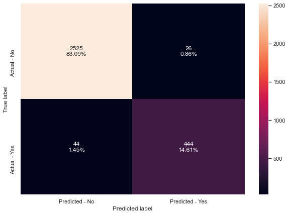

```python
#Calculating different metrics
scores_gbc_Rtuned=get_metrics_score(gbc_Rtuned,X_train,X_test,y_train,y_test)

# creating confusion matrix
make_confusion_matrix(gbc_Rtuned,y_test)
```

- Considering Test Recall as our target metric, this is a good model that can be prepped for production
- The GridSearch for GBClassifier took a time of 1 hr 4mins 47s
- The RandomsSearch took 26 mins 37s indicating a faster processing time by over 35 mins.

### Model Performance Comparison

```python
# defining list of models
models = [bagged,bag_Gtuned,bag_Rtuned,ada,ada_Gtuned,ada_Rtuned,gbc,gbc_Gtuned,gbc_Rtuned]
# defining empty lists to add train and test results
acc_train = []
acc_test = []
recall_train = []
recall_test = []
precision_train = []
precision_test = []

# looping through all the models to get the metrics score - Accuracy, Recall and Precision
for model in models:

    j = get_metrics_score(model, X_train,X_test,y_train,y_test, False)
    acc_train.append(j[0])
    acc_test.append(j[1])
    recall_train.append(j[2])
    recall_test.append(j[3])
    precision_train.append(j[4])
    precision_test.append(j[5])
```

```python
comparison_frame = pd.DataFrame({'Model':['Bagging Classifier','GridSearch Tuned Bagging Classifier',
                                          'RandomSearch Tuned Bagging Classifier','AdaBoost Classifier',
                                          'GridSearch Tuned Adaboost Classifier','RandomSearch Tuned Adaboost Classifier','GBClassifier',
                                          'GridSearch Tuned GBClassifier','RandomSearch Tuned GBClassifier',
                                          ],
                                          'Train_Accuracy': acc_train,
                                          'Test_Accuracy': acc_test,
                                          'Train_Recall': recall_train,
                                          'Test_Recall': recall_test,
                                          'Train_Precision': precision_train,
                                          'Test_Precision': precision_test})
comparison_frame.sort_values(by="Test_Recall", ascending=False)
```

|  | Model | Train_Accuracy | Test_Accuracy | Train_Recall | Test_Recall | Train_Precision | Test_Precision |
| --- | --- | --- | --- | --- | --- | --- | --- |
| 4 | GridSearch Tuned Adaboost Classifier | 0.992240 | 0.973676 | 0.971905 | 0.915984 | 0.979646 | 0.919753 |
| 5 | RandomSearch Tuned Adaboost Classifier | 0.992240 | 0.973676 | 0.971905 | 0.915984 | 0.979646 | 0.919753 |
| 7 | GridSearch Tuned GBClassifier | 0.992664 | 0.974663 | 0.971027 | 0.909836 | 0.983111 | 0.930818 |
| 8 | RandomSearch Tuned GBClassifier | 0.990124 | 0.976966 | 0.957858 | 0.909836 | 0.980234 | 0.944681 |
| 6 | GBClassifier | 0.975310 | 0.968411 | 0.885865 | 0.877049 | 0.957306 | 0.922414 |
| 1 | GridSearch Tuned Bagging Classifier | 0.993651 | 0.965449 | 0.967515 | 0.858607 | 0.992793 | 0.920879 |
| 2 | RandomSearch Tuned Bagging Classifier | 0.993651 | 0.965449 | 0.967515 | 0.858607 | 0.992793 | 0.920879 |
| 0 | Bagging Classifier | 0.996896 | 0.958539 | 0.983319 | 0.842213 | 0.997329 | 0.893478 |
| 3 | AdaBoost Classifier | 0.957675 | 0.953603 | 0.839333 | 0.838115 | 0.890960 | 0.868365 |